# Statistique Bayésienne

Marlène Chevalier

mars 2020

# 1 Sujet : attractivité des lycées de l’académie de Versailles

L’étude concerne l’attractivité des lycées de l’académie de Versailles en 2012. Elle est mesurée par établissement et par matière en attribuant un nombre de points à chaque couple (établissement, discipline). Celui - ci constitue le seuil de points de carrière à avoir pour un enseignant qui envisage une mutation dans l’établissement et dans une matière donnée. Nous allons étudier ce nombre de points dans le cadre bayésien.

Source : fichier **mutations.csv**

**Description rapide des données**

Ce fichier est constitué de 516 couples (établissement, discipline) différents (en ligne) et 22 variables explicatives. La variable d’intérêt, le nombre de points pour chaque etablissement et discipline est *Barre*. Les variables explicatives disponibles sont :

- les identifiants de l’établissement (code, nom, ville)
- les matières
- les effectifs, les taux bruts et attendus de réussite, des series du bac général
- les effectifs, les taux bruts et attendus d’accès au bac des classes de seconde et première
- les taux de réussite obtenus et attendus au bac

**Variables renommées**

| Variable_originale | Variable_renommee |
| --- | --- |
| effectif_presents_serie_l | effpre.l |
| effectif_presents_serie_es | effpre.es |
| effectif_presents_serie_s | effpre.s |
| taux_brut_de_reussite_serie_l | tbr.l |
| taux_brut_de_reussite_serie_es | tbr.es |
| taux_brut_de_reussite_serie_s | tbr.s |
| taux_reussite_attendu_serie_l | tra.l |
| taux_reussite_attendu_serie_es | tra.es |
| taux_brut_de_reussite_serie_s | tra.s |
| effectif_de_seconde | eff.2 |
| effectif_de_premiere | eff.1 |
| taux_acces_brut_seconde_bac | tab.2bac |
| taux_acces_attendu_seconde_bac | taa.2bac |
| taux_acces_brut_premiere_bac | tab.1bac |
| taux_acces_attendu_premiere_bac | taa.1bac |
| taux_brut_de_reussite_total_series | tbr.tot |
| taux_reussite_attendu_total_series | tra.tot |

**Distribution des points de mutation : Barre**

| Min_Barre | Mediane_Barre | Moyenne_Barre | Max_Barre |
| --- | --- | --- | --- |
| 21 | 196 | 322 | 2056 |

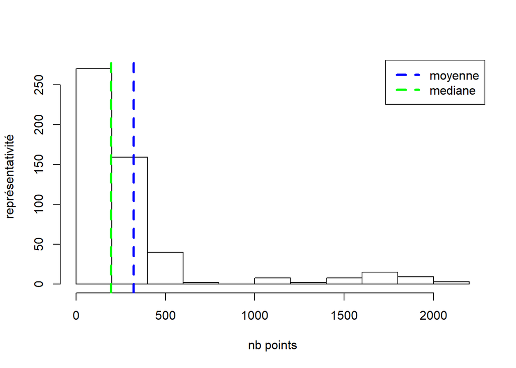

La distribution de *Barre* est décrite sur l’intervalle [21;2056] avec une forte concentration sur les petites valeurs (valeur médiane à 196 points).

**Barre par regroupement de matières**

| SCIENCE_SCI | LITTERAIRE_LIT | LANGUES_LVI | HIST.GEO_HGE | ECONOMIE_ECO | EPS | TECHNIQUE_TEC |
| --- | --- | --- | --- | --- | --- | --- |
| MATHS | LET ANGLAI | ALLEMAND | HIST. GEO. | SC.ECO.SOC | E. P. S | TEC |
| S. V.T. | LET ESPAGN | ANGLAIS |  |  |  |  |
| MATH.SC.PH | LET MODERN | ARTS PLAST |  |  |  |  |
| PHY.CHIMIE | LET.HIS.GE | ESPAGNOL |  |  |  |  |
|  | LETT CLASS | ITALIEN |  |  |  |  |
|  | PHILO |  |  |  |  |  |

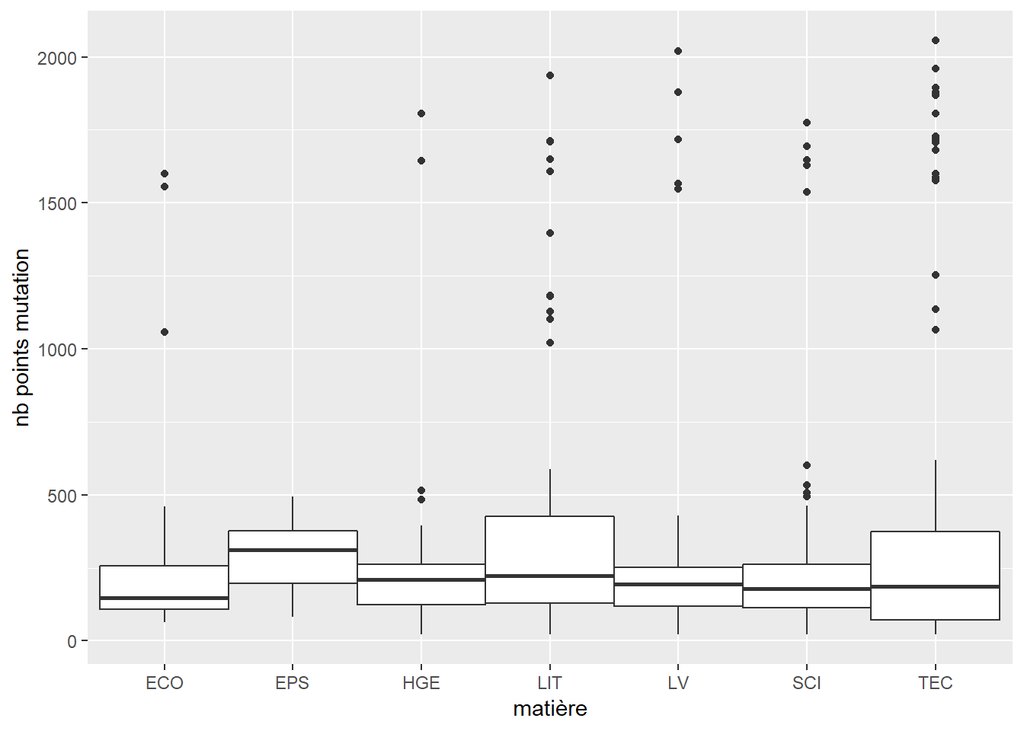

Le nombre moyen de points par type de matière est équivalent, avec un niveau un peu plus élévé pour l’EPS.

**Barre en fonction du taux de réussite au bac**

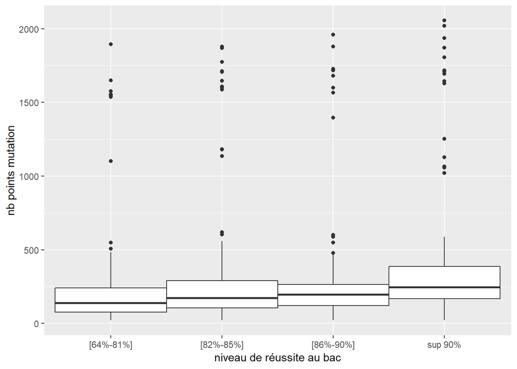

Le nombre moyen de points necessaires augmente légèrement avec le taux de réussite au bac.

**Corrélations**

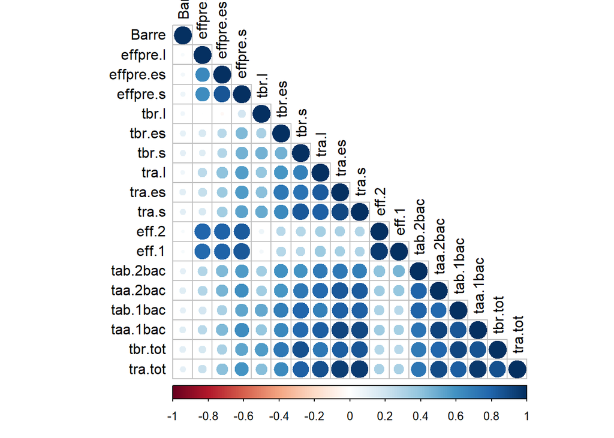

Nous observons de fortes corrélations entre :

- les variables effectifs des séries, en seconde et en première (variables eff) :  
  effpre.l / effpre.es / effpre.s / eff.1 /eff.2
- les taux de réussite au bac bruts et attendus (variables tbr et tra) sauf pour la section littéraire :  
  tbr.s /tba.s / tbr.es /tba.es / tbr.tot /tba.tot
- les taux d’accès au bac attendus et bruts (variables taa et tab), qui sont également corrélés au taux de réussite total au bac  
  tab.2bac / taa.2bac / tab.1bac / taa.1bac

# 2 Regression linéaire

Analyse sur l’ensemble sur le jeu de données complet

## 2.1 Regression linéaire bayésienne

Nous testerons 2 méthodes pour estimer les coefficients de regression linéaire bayésienne.

**Méthode 1 : Estimation des coefficients par l’espérance a posteriori**

Nous allons calculer une estimation des coefficients de la regression linéaire bayésienne (Beta) par leur espérance a posteriori. Nous utilisons pour cela la loi a priori de Zellner g et les coefficients estimés (betahat) par une regression linéaire gaussienne :

beta/sigma², X suit a posteriori loi normale :  
d’espérance = g/(g+1) x betahat  
de variance = (g/g+1) x s2 x (X tX)-1

Nous prenons g=n soit g=516

|  | coef_estime | pvaleur |
| --- | --- | --- |
| (Intercept) | -471.614 | 0.195 |
| Xeffpre.l | 0.777 | 0.685 |
| Xeffpre.es | 0.292 | 0.595 |
| Xeffpre.s | 0.010 | 0.504 |
| Xtbr.l | 3.116 | 0.892 |
| Xtbr.es | 4.802 | 0.877 |
| Xtbr.s | 9.367 | 0.932 |
| Xtra.l | -14.257 | 0.018 |
| Xtra.es | 3.807 | 0.680 |
| Xtra.s | -4.291 | 0.325 |
| Xeff.2 | 0.043 | 0.528 |
| Xeff.1 | -0.351 | 0.310 |
| Xtab.2bac | 10.724 | 0.973 |
| Xtaa.2bac | -7.064 | 0.214 |
| Xtab.1bac | -20.347 | 0.027 |
| Xtaa.1bac | 34.377 | 0.966 |
| Xtbr.tot | -5.382 | 0.336 |
| Xtra.tot | -4.064 | 0.426 |

Nous constatons que seules 2 variables explicatives sont significativement différentes de zéro (pvaleur<5%):

- taux de réussite attendu au bac en section L : betahat (tra.l) = -14.257
- taux d’accès brut de la premiere au bac : betahat (tab.1bac) = -20.347

**Méthode 2 : Fonction regresssion bayésienne : bas.lm**

Ici nous utilisons la fonction *bas.lm* du package *BAS* . L’état des coefficients obtenu présente pour chaque coefficient de la régression :

*postmean* : la moyenne marginale a posteriori du coefficient  
*post SD* : l’écart-type a posteriori du coefficient  
*post p(B != 0)* : probabilité marginale que le coefficient soit différent de 0

```
##
##  Marginal Posterior Summaries of Coefficients:
##
##  Using  BMA
##
##  Based on the top  131072 models
##            post mean   post SD     post p(B != 0)
## Intercept   3.219e+02   1.859e+01   1.000e+00
## effpre.l    1.785e-03   7.402e-02   5.119e-03
## effpre.es   1.427e-03   5.510e-02   5.742e-03
## effpre.s    3.513e-03   5.737e-02   9.093e-03
## tbr.l       1.265e-02   2.216e-01   7.618e-03
## tbr.es      1.176e-01   7.885e-01   2.781e-02
## tbr.s       1.436e-01   9.247e-01   3.044e-02
## tra.l      -5.118e-02   8.615e-01   1.334e-02
## tra.es      3.450e-01   1.540e+00   5.806e-02
## tra.s       2.569e-01   1.261e+00   4.973e-02
## eff.2       7.943e-05   1.223e-02   5.059e-03
## eff.1       5.093e-05   1.329e-02   5.076e-03
## tab.2bac    1.834e-01   1.048e+00   3.680e-02
## taa.2bac    8.274e-01   2.566e+00   1.076e-01
## tab.1bac    2.133e-01   1.318e+00   3.349e-02
## taa.1bac    1.691e+00   4.166e+00   1.658e-01
## tbr.tot     4.122e-01   1.781e+00   6.023e-02
## tra.tot     2.648e-01   1.671e+00   4.720e-02
```

Les probabilités que les coefficients soient différents de 0 sont toutes très faibles . La plus importante est de 16.6% et concerne le taux accès attendu de la première au bac (taa.1bac).

Les graphiques de la regression bayésienne :

- Le premier est un graphique des résidus et des valeurs ajustées dans le modèle bayésien de calcul de la moyenne.
- Le second graphique montre la probabilité cumulative des modèles dans l’ordre où ils sont échantillonnés.
- Le troisième graphique montre la dimension de chaque modèle (le nombre de coefficients de régression, y compris l’interception) par rapport au log de la probabilité marginale du modèle.
- Le dernier graphique montre les probabilités marginales d’inclusion postérieure pour chacune des covariables. Plus ces probabilités sont fortes (> 0,5 en rouge), plus les covariables seront un facteur explicatif important des données. Lorsque ces probabilités sont faibles, les covariables sont fortement corrélées.

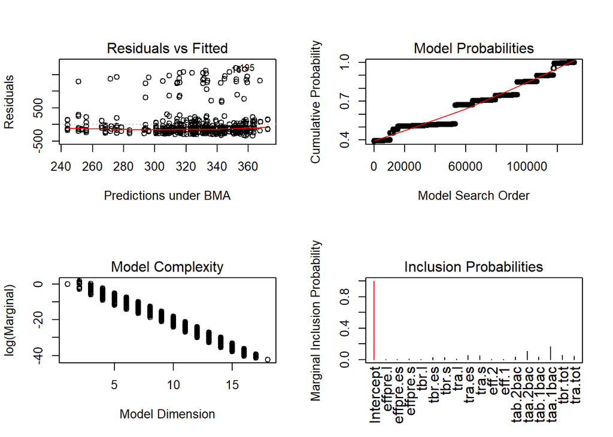

Ce modèle n’apparait pas comme satisfaisant car il ne présente pas un ajustement satisfaisant (Graphe : variance importante). De plus, les probabilités marginales des covariables sont faibles, ce qui présage d’une importante collinéarité des covariables.

## 2.2 Regression linéaire gaussienne

```
##
## Call:
## lm(formula = Barre ~ ., data = dred)
##
## Residuals:
##     Min      1Q  Median      3Q     Max
## -429.72 -205.90 -122.25   -8.55 1645.96
##
## Coefficients:
##               Estimate Std. Error t value Pr(>|t|)
## (Intercept) -4.725e+02  5.586e+02  -0.846   0.3980
## effpre.l     7.781e-01  1.638e+00   0.475   0.6351
## effpre.es    2.924e-01  1.234e+00   0.237   0.8128
## effpre.s     9.694e-03  1.019e+00   0.010   0.9924
## tbr.l        3.122e+00  2.559e+00   1.220   0.2232
## tbr.es       4.811e+00  4.205e+00   1.144   0.2531
## tbr.s        9.385e+00  6.383e+00   1.470   0.1421
## tra.l       -1.428e+01  6.879e+00  -2.077   0.0383 *
## tra.es       3.814e+00  8.261e+00   0.462   0.6445
## tra.s       -4.299e+00  9.586e+00  -0.448   0.6540
## eff.2        4.306e-02  6.229e-01   0.069   0.9449
## eff.1       -3.521e-01  7.182e-01  -0.490   0.6242
## tab.2bac     1.074e+01  5.655e+00   1.900   0.0580 .
## taa.2bac    -7.077e+00  9.038e+00  -0.783   0.4340
## tab.1bac    -2.039e+01  1.071e+01  -1.904   0.0575 .
## taa.1bac     3.444e+01  1.916e+01   1.797   0.0729 .
## tbr.tot     -5.392e+00  1.288e+01  -0.419   0.6757
## tra.tot     -4.072e+00  2.202e+01  -0.185   0.8534
## ---
## Signif. codes:  0 '***' 0.001 '**' 0.01 '*' 0.05 '.' 0.1 ' ' 1
##
## Residual standard error: 422.4 on 498 degrees of freedom
## Multiple R-squared:  0.04068,    Adjusted R-squared:  0.007931
## F-statistic: 1.242 on 17 and 498 DF,  p-value: 0.2267
```

## 2.3 Choix de modèles

### 2.3.1 Choix de modèle regression bayésien: GIBBS

Il s’agit de choisir les covariables à partir de l’algorithme de GIBBS. Cet algorithme donne la probabilité que chaque covariable soit retenue comme variable explicative : la probabilité que gamma(covariable j) = 1. Plus cette probabilité est proche de 1, plus il est probable que gamma(covariable j) soit égal à 1, et donc plus il est probable que la covariable j soit signicative pour expliquer la variable réponse (ici Barre).

**Algorithme de GIBBS sur le jeu complet de données (variables numériques)**

```r
# fonction pour calculer la log-vraisemblance marginale

marglkd = function(gamma, X, g=n){
  q=sum(gamma)
  X1=X[ ,c(TRUE,gamma)]
  if(q==0){return( -n/2 * log(t(Y)%*%Y))}
  m = -q/2*log(g+1) -
    n/2*log(t(Y)%*%Y - g/(g+1)* t(Y)%*% X1 %*%
              solve(t(X1)%*%X1) %*%t(X1)%*%Y)
return(m)
 }
```

```r
set.seed(159)

# algorithme de Gibbs
niter = 1e4 # nombre d'itérations
pcol=17 # nombre de covariables
gamma = matrix(F, nrow = niter, ncol = pcol) # initialisation à faux de la matrice gamma (ninter,ncol)
gamma0 = sample(c(T, F), size = pcol, replace = TRUE) # initialisation aléatoire du vecteur gamma0 : valeurs de vrai et faux pour chaque covariable
lkd = rep(0, niter) # initialisation des ninter valeurs de vraissemblances à 0
modelnumber = rep(0, niter) # initialisation des ninter nombre de modèle à 0

oldgamma = gamma0
for(i in 1:niter){
  newgamma = oldgamma
  for(j in 1:pcol){
    g1 = newgamma; g1[j]=TRUE
    g2 = newgamma; g2[j]=FALSE
    ml1 = marglkd(g1, X,n)
    ml2 = marglkd(g2, X,n)
    p = c(ml1,ml2)-min(ml1,ml2)
    newgamma[j] = sample(c(T,F), size=1, prob=exp(p))
  }
  gamma[i,] = newgamma
  lkd[i] = marglkd(newgamma, X )
  modelnumber[i] = sum(newgamma*2^(0:16))
  oldgamma = newgamma
}

pgamma=colMeans(gamma) # probabilité que l'indicatrice de chaque covariable soit =1
rbind(colnames(X[,-1]),pgamma)
```

```
##        [,1]       [,2]        [,3]       [,4]     [,5]     [,6]
##        "effpre.l" "effpre.es" "effpre.s" "tbr.l"  "tbr.es" "tbr.s"
## pgamma "0.0447"   "0.0434"    "0.0494"   "0.0531" "0.0832" "0.0861"
##        [,7]     [,8]     [,9]     [,10]    [,11]    [,12]      [,13]
##        "tra.l"  "tra.es" "tra.s"  "eff.2"  "eff.1"  "tab.2bac" "taa.2bac"
## pgamma "0.1228" "0.107"  "0.1005" "0.0469" "0.0465" "0.0908"   "0.1912"
##        [,14]      [,15]      [,16]     [,17]
##        "tab.1bac" "taa.1bac" "tbr.tot" "tra.tot"
## pgamma "0.0809"   "0.3336"   "0.1213"  "0.1167"
```

**Convergence**

Il s’agit de regarder la convergence de l’algorithme de GIBBS en observant les trajectoires et leur stationnarité.

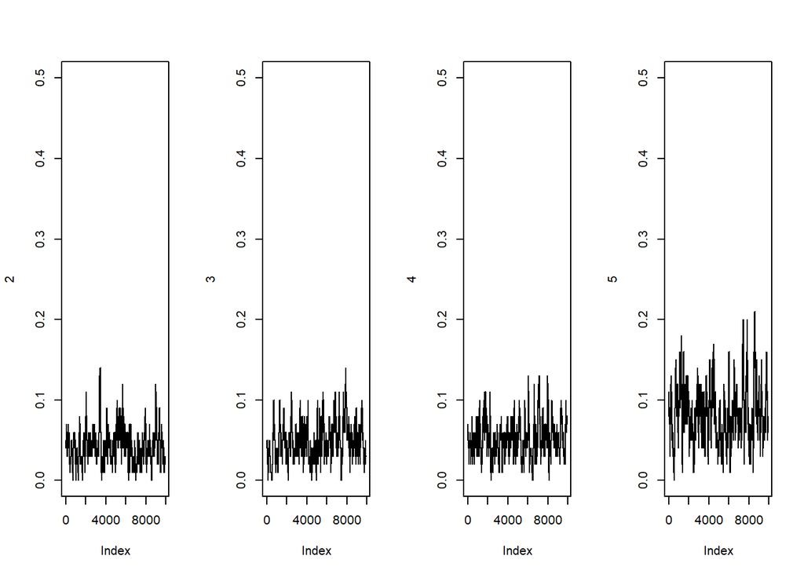

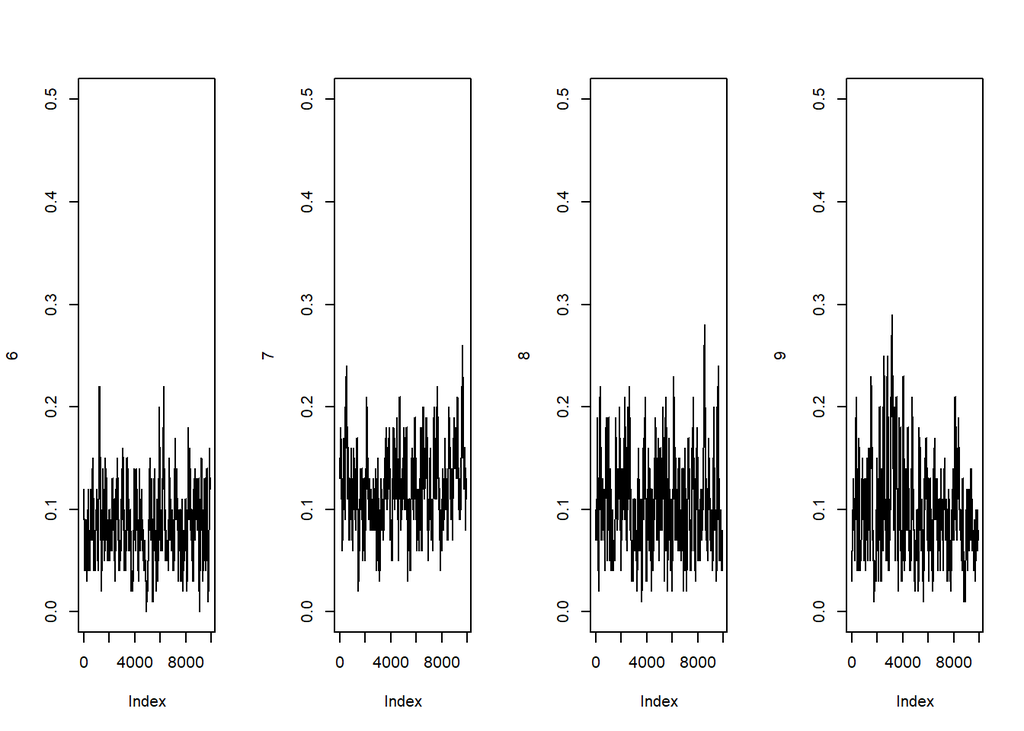

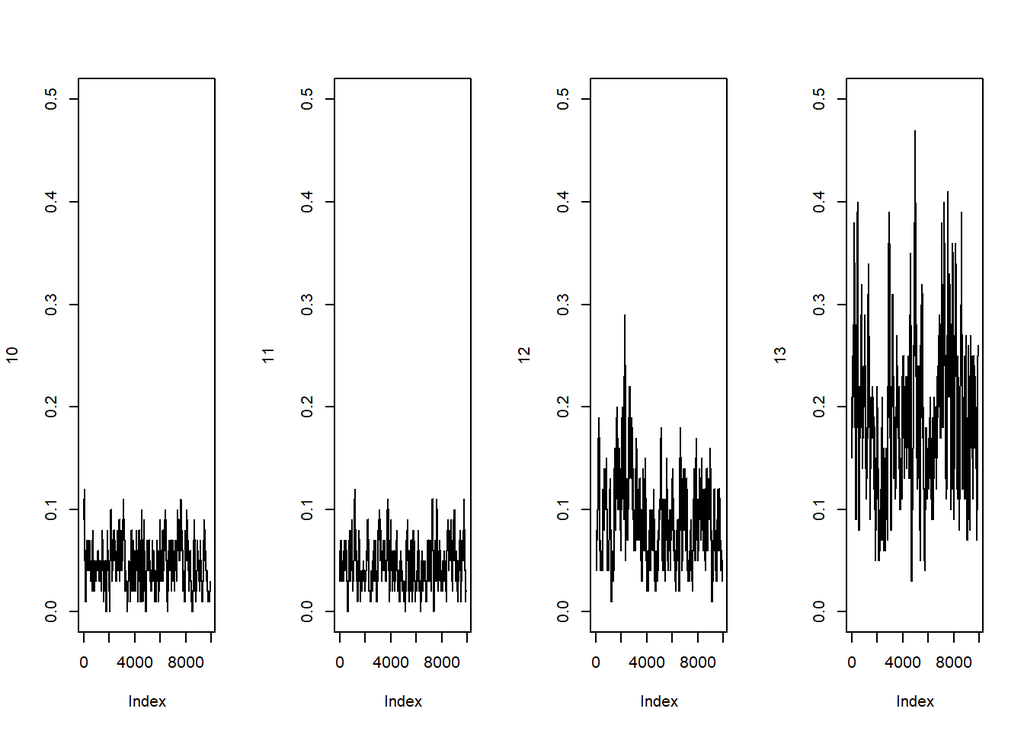

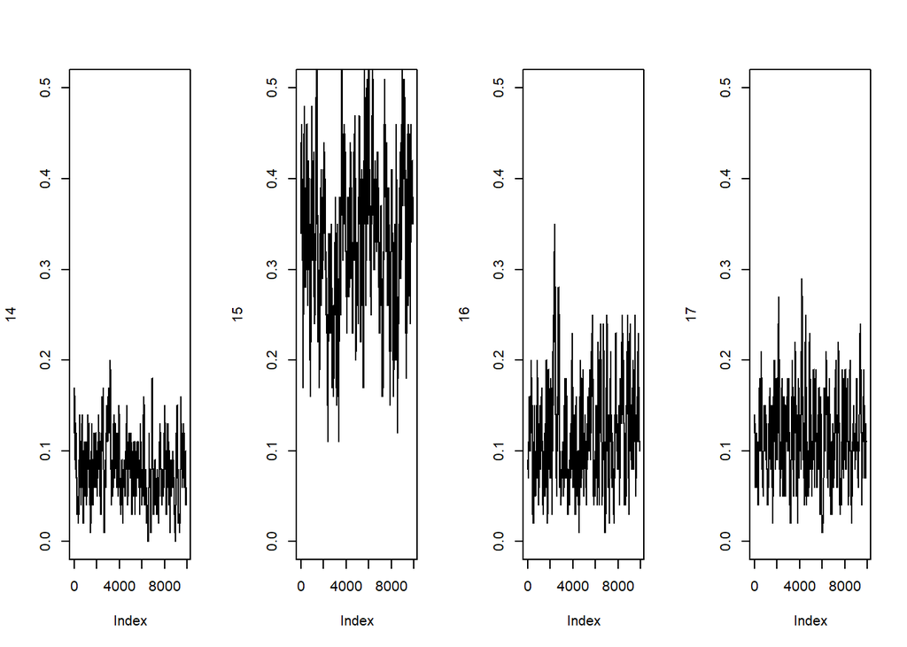

**Algorithme de GIBBS sur le jeu avec des données non corrélées**

Testons l’algorithme de GIBBS sur un jeu de données réduits au variables non correlées. En fonction des correlations constatées précédemment, nous garderons les variables :

- eff.2
- tab.2bac
- tbr.l
- tra.l
- tbr.tot

Sur le jeu de données réduit à des variables non corrélées, deux d’entre elles ont une forte probabilité d’être retenue dans le modèle : le taux brut de réussite “tbr.tot” (60.3%) et le taux acces brut de la seconde au bac “tab.2bac”" (34.9%).

### 2.3.2 Choix de modèle regression linéaire

Nous utilisons ici la méthode de choix *step*, qui cumule les examens ascendant et descendant des variables (*both*).

**Regression lineéaire sur le jeu complet de données (variables numériques)**

Sur l’ensemble des variables explicatives numériques, 2 sont choisies par cette méthode : le taux de réussite attendu de la serie L (tra.l) et le taux accès attendu de première au bac (taa.1bac). L’AIC obtenu est de 6235.

**Regression linéaire sur le jeu restreint de données**

Le choix de modèle à partir d’un nombre plus resteint de covariables (conservation des variables non corrélées), donne un AIC plus important (6238) que sur le modèle complet. La méthode sur jeu retreint ne retient que le taux de réussite totale brut.

**En conclusion** : il semble que les covariables proposées dans ce jeu de données ne soient pas les plus pertinentes pour expliquer le nombre de points nécessaires à l’obtention d’une mutation dans un lycée de l’académie de Versailles.

## 2.4 Analyse des mutations en mathématiques et anglais

La méthode de calcul des coefficients et leur significativité est celle de la regression bayésienne par l’espérance a posteriori (méthode 1).

L’enseignement d’anglais correspond aux matières : ANGLAIS et LET ANGLAIS. L’enseignement des mathématiques correspond à la matière : MATHS.

Les coefficients et leur pvalue obtenus pour les enseignements d’anglais et de maths sont dans le tableau ci-dessous.

|  | coef_estime_ANG | pvaleur_ANG | coef_estime_MATH | pvaleur_MATH |
| --- | --- | --- | --- | --- |
| (Intercept) | -647.186 | 0.350 | 64.691 | 0.560 |
| X.angeffpre.l | -1.678 | 0.386 | 0.399 | 0.643 |
| X.angeffpre.es | 1.129 | 0.662 | -0.379 | 0.325 |
| X.angeffpre.s | -0.251 | 0.456 | 1.153 | 0.941 |
| X.angtbr.l | -6.121 | 0.117 | -3.607 | 0.026 |
| X.angtbr.es | 5.390 | 0.726 | 7.126 | 0.975 |
| X.angtbr.s | 2.816 | 0.575 | 1.471 | 0.619 |
| X.angtra.l | 6.628 | 0.638 | -4.058 | 0.205 |
| X.angtra.es | 31.749 | 0.965 | -6.097 | 0.164 |
| X.angtra.s | -8.409 | 0.337 | -2.021 | 0.391 |
| X.angeff.2 | 1.265 | 0.788 | 0.790 | 0.958 |
| X.angeff.1 | -2.101 | 0.140 | -1.381 | 0.006 |
| X.angtab.2bac | 9.515 | 0.760 | 12.879 | 0.991 |
| X.angtaa.2bac | -21.631 | 0.172 | -9.077 | 0.077 |
| X.angtab.1bac | -51.894 | 0.021 | -12.388 | 0.087 |
| X.angtaa.1bac | 77.861 | 0.935 | 5.547 | 0.665 |
| X.angtbr.tot | 44.316 | 0.923 | 1.431 | 0.559 |
| X.angtra.tot | -78.655 | 0.074 | 11.132 | 0.765 |

# 3 Loi de Pareto

## 3.1 Générer une loi de Pareto

La loi de pareto est générée pour une variable Z à valeur sur [m,+∞] avec m>0 et α>0  
Z~Pareto(m,α)

Pour generer cette loi, nous utiliserons :  
package : EnvStats fonction : rpareto(n=taille de l’échantillon, location=m, shape = α)

ici m =21 (min du nombre de points observés pour Barre).

densité de la variable Z selon 5 valeurs de α :

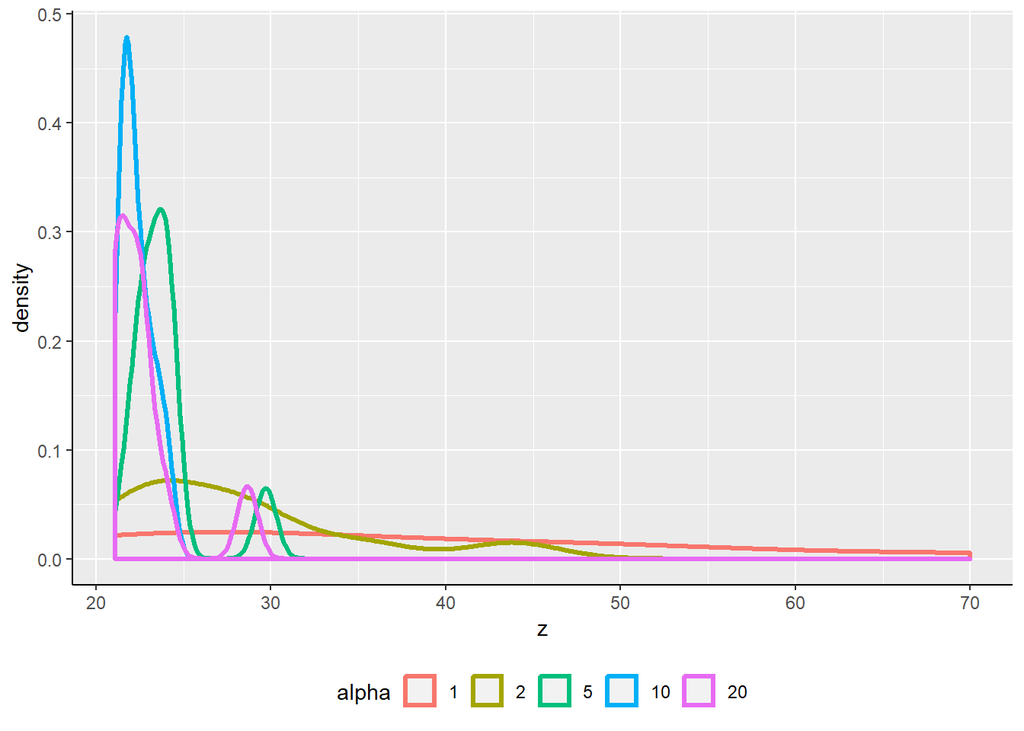

Plus la valeur d’alpha augmente, plus la densitié est forte sur les petites valeurs de Z et marque 2 oscillations, puis tend vers 0 rapidement. Cependant, il semble qu’à partir d’une valeur seuil d’alpha (ici α=10), la densité perde en intensité et revienne à des niveaux déjà atteints par des valeurs d’alpha inférieures à ce seuil (ici la densité pour α=20 revient à celle pour α=5).

## 3.2 Loi a priori du paramètre α

Sans idée particulière sur la loi de α, testons la loi a priori de Jeffrey’s π(α): cette loi est proportionnelle à la racine carrée de l’information de Fisher, notée I(α).

loi a priori de Jeffrey’s : π(α) ∝ sqrt(I(α))

information de Fisher : I(α)=-E[∂²/∂α² (log L(α/Z))]

log vraisemblance : log L(α/Z)

fonction de vraisemblance : L(α/Z)= Produit(i=1 à n) Pareto(m,α)  
L(α/Z)=Produit(i=1 à n) [α x (m puissance(α)) / (Z puissance(α+1))]

On trouve I(α)=n/α², la loi a priori de Jeffrey’s est proportionnelle à sqrt(n)/α

## 3.3 Loi a posteriori du paramètre α

La loi a posteriori de α s’écrit : π(α|Z) ∝ π(α)L(α|Z)

π(α)L(α|Z)=(sqrt(n)/α) X (α puissance(n)) X(m puissance(nα)) X exp(-(α+1) X somme(i=1 à n)[logZi])

π(α|Z) ∝ (α puissance(n-1)) X (m puissance(nα)) X exp(-(α+1) X somme(i=1 à n)[logZi])

```r
posterior = function (alpha, Z){
  m=21
  n= dim[1]
  post = (alpha^(n-1)) * (m^(n*alpha)) * exp(-(alpha+1)*sum(log(Z)))
  return (post)
  }
```